# PRÁCTICA 1 DE ANÁLISIS DE COMPONENTES PRINCIPALES

Máster en Data Science para Finanzas - CUNEF

Juan Manuel López Zafra

Cargamos `factoextra`, `factomineR` y la librería de datos `iris`, de la que quitamos “Species” para hacer el ACP.

```r
library(factoextra)
library(FactoMineR)
data(iris)
summary(iris)
```

```
  Sepal.Length    Sepal.Width     Petal.Length    Petal.Width          Species
 Min.   :4.300   Min.   :2.000   Min.   :1.000   Min.   :0.100   setosa    :50
 1st Qu.:5.100   1st Qu.:2.800   1st Qu.:1.600   1st Qu.:0.300   versicolor:50
 Median :5.800   Median :3.000   Median :4.350   Median :1.300   virginica :50
 Mean   :5.843   Mean   :3.057   Mean   :3.758   Mean   :1.199
 3rd Qu.:6.400   3rd Qu.:3.300   3rd Qu.:5.100   3rd Qu.:1.800
 Max.   :7.900   Max.   :4.400   Max.   :6.900   Max.   :2.500
```

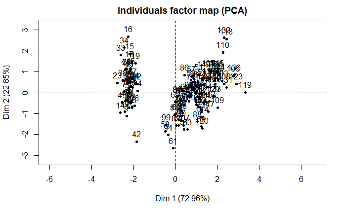

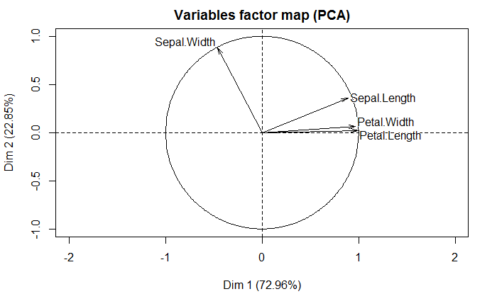

```r
acp= PCA(iris[,-5], graph=T)
```

Extraemos los autovalores y observamos la varianza explicada. LO hacemos tanto con `factominer`

```r
acp$eig
```

```
       eigenvalue percentage of variance cumulative percentage of variance
comp 1 2.91849782             72.9624454                          72.96245
comp 2 0.91403047             22.8507618                          95.81321
comp 3 0.14675688              3.6689219                          99.48213
comp 4 0.02071484              0.5178709                         100.00000
```

como con `factoextra`

```r
get_eig(acp)
```

```
      eigenvalue variance.percent cumulative.variance.percent
Dim.1 2.91849782       72.9624454                    72.96245
Dim.2 0.91403047       22.8507618                    95.81321
Dim.3 0.14675688        3.6689219                    99.48213
Dim.4 0.02071484        0.5178709                   100.00000
```

y realizamos en *screeplot* o gráfico de sedimentación

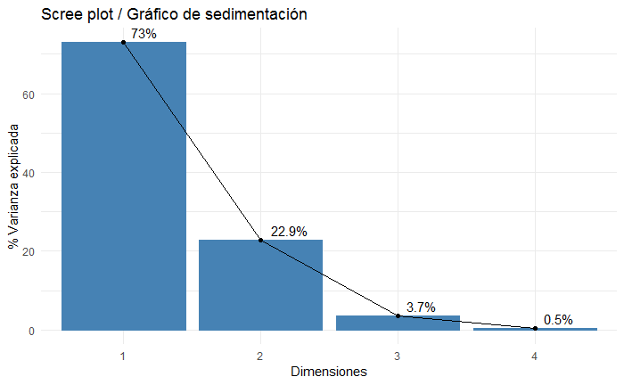

```r
fviz_eig(acp, addlabels=TRUE, hjust = -0.3)+
        labs(title="Scree plot / Gráfico de sedimentación", x="Dimensiones", y="% Varianza explicada")+
        theme_minimal()
```

# Relación de las variables con los componentes principales

Podemos verlo a partir de `factoextra`como sigue:

```r
var=get_pca_var(acp)
var
```

```
Principal Component Analysis Results for variables
 ===================================================
  Name       Description
1 "$coord"   "Coordinates for the variables"
2 "$cor"     "Correlations between variables and dimensions"
3 "$cos2"    "Cos2 for the variables"
4 "$contrib" "contributions of the variables"
```

mientras que, con `factominer`, sólo tenemos que ejecutar el el objeto generado más arriba, *acp*:

```r
acp
```

```
**Results for the Principal Component Analysis (PCA)**
The analysis was performed on 150 individuals, described by 4 variables
*The results are available in the following objects:

   name               description
1  "$eig"             "eigenvalues"
2  "$var"             "results for the variables"
3  "$var$coord"       "coord. for the variables"
4  "$var$cor"         "correlations variables - dimensions"
5  "$var$cos2"        "cos2 for the variables"
6  "$var$contrib"     "contributions of the variables"
7  "$ind"             "results for the individuals"
8  "$ind$coord"       "coord. for the individuals"
9  "$ind$cos2"        "cos2 for the individuals"
10 "$ind$contrib"     "contributions of the individuals"
11 "$call"            "summary statistics"
12 "$call$centre"     "mean of the variables"
13 "$call$ecart.type" "standard error of the variables"
14 "$call$row.w"      "weights for the individuals"
15 "$call$col.w"      "weights for the variables"
```

En cuanto a las coordenadas y contribuciones de las variables al sistema de componentes principales, en `factoextra`las primeras vienen dadas por

```r
var$coord
```

```
                  Dim.1      Dim.2       Dim.3       Dim.4
Sepal.Length  0.8901688 0.36082989 -0.27565767 -0.03760602
Sepal.Width  -0.4601427 0.88271627  0.09361987  0.01777631
Petal.Length  0.9915552 0.02341519  0.05444699  0.11534978
Petal.Width   0.9649790 0.06399985  0.24298265 -0.07535950
```

Si quisiémos las coordenadas de las observaciones, haríamos, con `factominer`,

```r
acp$ind
```

[output not shown]

[output cut: 467 more lines]

mientras que las contribuciones (en %) de las variables a los componentes, siendo TC el coseno cuadrado total del componente y definidas como
$$\dfrac{var.cos^2 \times 100}{TC}$$
se obtienen mediante

```r
var$contrib
```

```
                 Dim.1       Dim.2     Dim.3     Dim.4
Sepal.Length 27.150969 14.24440565 51.777574  6.827052
Sepal.Width   7.254804 85.24748749  5.972245  1.525463
Petal.Length 33.687936  0.05998389  2.019990 64.232089
Petal.Width  31.906291  0.44812296 40.230191 27.415396
```

El $cos^2$ mide la calidad de la representación del espacio de componentes principales; podemos obtenerlo mediante

```r
var$cos2
```

```
                 Dim.1       Dim.2       Dim.3        Dim.4
Sepal.Length 0.7924004 0.130198208 0.075987149 0.0014142127
Sepal.Width  0.2117313 0.779188012 0.008764681 0.0003159971
Petal.Length 0.9831817 0.000548271 0.002964475 0.0133055723
Petal.Width  0.9311844 0.004095980 0.059040571 0.0056790544
```

y representarlo gráficamente con la librería `corrplot`

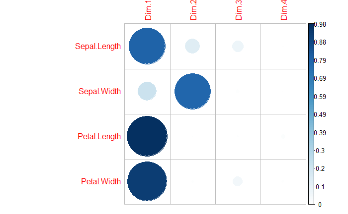

```r
library(corrplot)
corrplot(var$cos2, is.corr=FALSE)
```

La correlación entre una variable y cada componente principal se emplea como sistema de coordenadas en el espacio de componentes principales; podemos obtenerlas fácilmente con la siguiente función:

```r
var$coord
```

```
                  Dim.1      Dim.2       Dim.3       Dim.4
Sepal.Length  0.8901688 0.36082989 -0.27565767 -0.03760602
Sepal.Width  -0.4601427 0.88271627  0.09361987  0.01777631
Petal.Length  0.9915552 0.02341519  0.05444699  0.11534978
Petal.Width   0.9649790 0.06399985  0.24298265 -0.07535950
```

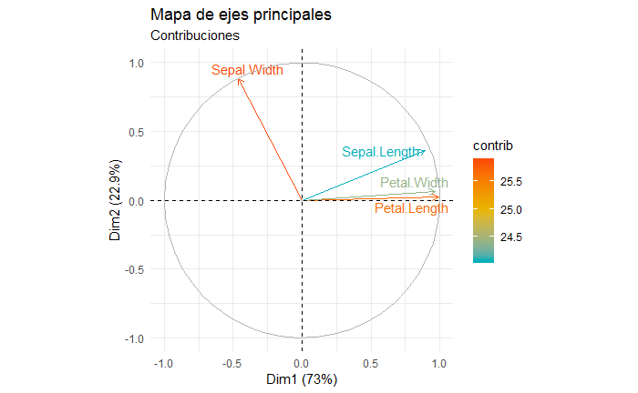

```r
fviz_pca_var(acp, col.var="contrib",
             gradient.cols = c("#00AFBB", "#E7B800", "#FC4E07"), repel=TRUE) +
                              labs(title="Mapa de ejes principales", subtitle="Contribuciones")+
        theme_minimal()
```

o también, si preferimos observar el $cos^2$, como

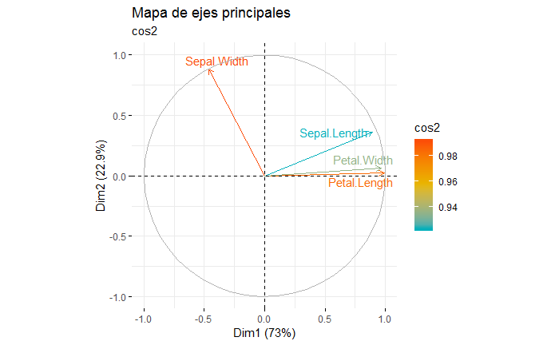

```r
fviz_pca_var(acp, col.var = "cos2",
             gradient.cols = c("#00AFBB", "#E7B800", "#FC4E07"),
             repel = TRUE )+
             labs(title="Mapa de ejes principales", subtitle="cos2")
```

La interpretación del gráfico es sencilla, pues tenemos tanto la información acerca de la asociación entre las variables (las positivamente correladas se agruparán, mientras que las que lo están de forma negativa se encontrarán en cuadrantes opuestos) como la calidad de la representación del espacio de componentes en virtud de la longitud de la flecha que representa la variable: a mayor longitud, mayor calidad, y viceversa.

Las dos medidas anteriores están íntimamente relacionadas, como es fácil entender; un gráfico de barras de del $cos^2$ nos permite ver esa relación:

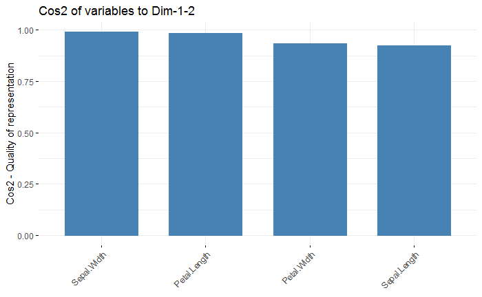

```r
fviz_cos2(acp, choice = "var", axes = 1:2)
```

Para una variable dada, la suma de los $cos^2$ en todos componentes es igual a 1, por lo que ya sabemos que el $cos^2$ es lo que denominamos *comunalidad de la variable*.

Las correlaciones de las observaciones *(ind)* o variables *(var)* las obtenemos en `factoextra` como

```r
var$cor
```

```
                  Dim.1      Dim.2       Dim.3       Dim.4
Sepal.Length  0.8901688 0.36082989 -0.27565767 -0.03760602
Sepal.Width  -0.4601427 0.88271627  0.09361987  0.01777631
Petal.Length  0.9915552 0.02341519  0.05444699  0.11534978
Petal.Width   0.9649790 0.06399985  0.24298265 -0.07535950
```

mientras que la comunalidad mediante

```r
var$cos2
```

```
                 Dim.1       Dim.2       Dim.3        Dim.4
Sepal.Length 0.7924004 0.130198208 0.075987149 0.0014142127
Sepal.Width  0.2117313 0.779188012 0.008764681 0.0003159971
Petal.Length 0.9831817 0.000548271 0.002964475 0.0133055723
Petal.Width  0.9311844 0.004095980 0.059040571 0.0056790544
```

Podemos comprobar que, efectivamente, el cuadrado de las coordenadas es igual al $cos^2$:

```r
var$coord^2
```

```
                 Dim.1       Dim.2       Dim.3        Dim.4
Sepal.Length 0.7924004 0.130198208 0.075987149 0.0014142127
Sepal.Width  0.2117313 0.779188012 0.008764681 0.0003159971
Petal.Length 0.9831817 0.000548271 0.002964475 0.0133055723
Petal.Width  0.9311844 0.004095980 0.059040571 0.0056790544
```

Y, asimismo, que, como hemos señalado, podemos obtener tanto la comunalidad de cada variable como su autovalor de la forma siguiente:

```r
x=var$coord[,1]
y=var$coord[1,]
sum(x^2)
```

```
[1] 2.918498
```

```r
sum(y^2)
```

```
[1] 1
```

Obtenemos ahora el autovalor del primer componente y la contribución de la primera variable a la explicación del primer componente:

```r
z=var$cos2[,1] # cos2 del CP1
sum(z) # cos2 total del CP1 (Autovalor del CP1)
```

```
[1] 2.918498
```

```r
z[1]/sum(z)*100 # contribución de la primera variable a la explicaci?n del CP1
```

```
Sepal.Length
    27.15097
```

Actuamos ahora de forma específica con `factominer`: las coordenadas,

```r
acp$var$coord
```

```
                  Dim.1      Dim.2       Dim.3       Dim.4
Sepal.Length  0.8901688 0.36082989 -0.27565767 -0.03760602
Sepal.Width  -0.4601427 0.88271627  0.09361987  0.01777631
Petal.Length  0.9915552 0.02341519  0.05444699  0.11534978
Petal.Width   0.9649790 0.06399985  0.24298265 -0.07535950
```

las correlaciones,

```r
acp$var$cor
```

```
                  Dim.1      Dim.2       Dim.3       Dim.4
Sepal.Length  0.8901688 0.36082989 -0.27565767 -0.03760602
Sepal.Width  -0.4601427 0.88271627  0.09361987  0.01777631
Petal.Length  0.9915552 0.02341519  0.05444699  0.11534978
Petal.Width   0.9649790 0.06399985  0.24298265 -0.07535950
```

las comunalidades o $cos^2$,

```r
acp$var$cos2
```

```
                 Dim.1       Dim.2       Dim.3        Dim.4
Sepal.Length 0.7924004 0.130198208 0.075987149 0.0014142127
Sepal.Width  0.2117313 0.779188012 0.008764681 0.0003159971
Petal.Length 0.9831817 0.000548271 0.002964475 0.0133055723
Petal.Width  0.9311844 0.004095980 0.059040571 0.0056790544
```

y por último las contribuciones de las variables a los componentes

```r
acp$var$contrib
```

```
                 Dim.1       Dim.2     Dim.3     Dim.4
Sepal.Length 27.150969 14.24440565 51.777574  6.827052
Sepal.Width   7.254804 85.24748749  5.972245  1.525463
Petal.Length 33.687936  0.05998389  2.019990 64.232089
Petal.Width  31.906291  0.44812296 40.230191 27.415396
```

En cuanto a la contribución de las variables a cada uno de los ejes principales, procederemos como sigue:

- Para el eje 1,

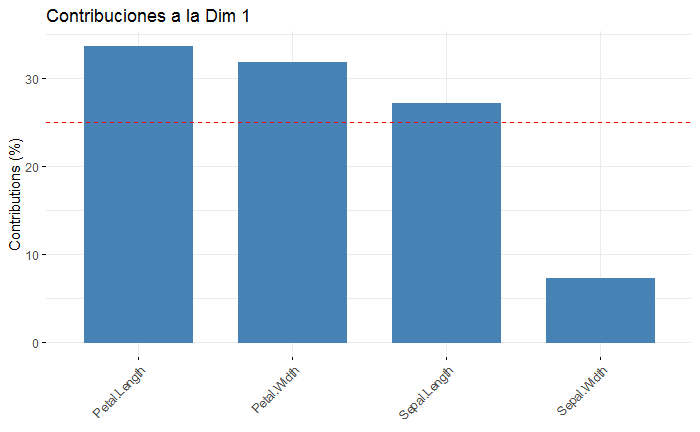

```r
fviz_contrib(acp, choice="var", axes = 1 )+
        labs(title = "Contribuciones a la Dim 1")
```

- Para el eje 2,

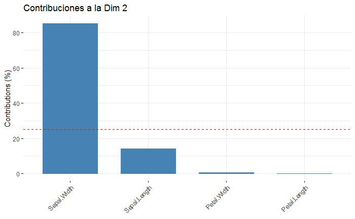

```r
fviz_contrib(acp, choice="var", axes = 2 )+
        labs(title = "Contribuciones a la Dim 2")
```

- Para ambos ejes,

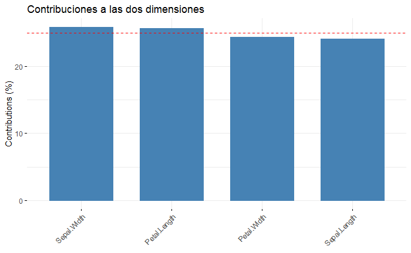

```r
fviz_contrib(acp, choice="var", axes = 1:2)+
        labs(title = "Contribuciones a las dos dimensiones")
```

# Extraccción de resultados para individuos

La librería `factoextra` nos permite obtener los resultados de los individuos en el espacio de componentes como sigue:

```r
ind = get_pca_ind(acp)
ind
```

```
Principal Component Analysis Results for individuals
 ===================================================
  Name       Description
1 "$coord"   "Coordinates for the individuals"
2 "$cos2"    "Cos2 for the individuals"
3 "$contrib" "contributions of the individuals"
```

Como podemos obsrvar, tenemos la misma información que respecto de las variables, pero al nivel de detalle del individuo: sus coordenadas (que nos permitirán efectuar un *mapa* en un espacio de dos o tres dimensiones), el $cos^2$ y la contribución a la explicación del eje.

Por ejemplo, si queremos las coordenadas de los individuos u observaciones en el plano de los ejes principales, haremos

```r
head(ind$coord)
```

```
      Dim.1      Dim.2       Dim.3       Dim.4
1 -2.264703  0.4800266 -0.12770602 -0.02416820
2 -2.080961 -0.6741336 -0.23460885 -0.10300677
3 -2.364229 -0.3419080  0.04420148 -0.02837705
4 -2.299384 -0.5973945  0.09129011  0.06595556
5 -2.389842  0.6468354  0.01573820  0.03592281
6 -2.075631  1.4891775  0.02696829 -0.00660818
```

que, como dice bastante poco, es mejor representar en un espacio 2D, que dotamos de las siguientes características:

- `repel = TRUE` para evitar solapamientos
- Control automático del color de los indiv mediante la opción `cos2`, calidad de los individuos sobre el mapa de ejes; mejor emplear sólo puntos,
- Gradiente de color

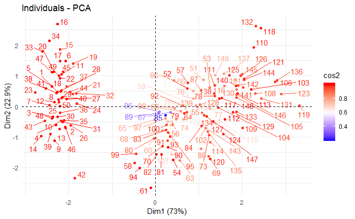

```r
fviz_pca_ind(acp, repel = T, col.ind = "cos2")+
        scale_color_gradient2(low="blue", mid="white",
                              high="red", midpoint=0.6)+
        theme_minimal()
```

Como ya hemos señalado, $cos2^$ representa la comunalidad de la variable en el factor, el cuadrado de la carga factorial; su suma por factores es uno.

Parece observarse disposiciones de las observaciones por grupos; procedemos a identificarlos:

- Grupos por colores, opción `habillage=iris$Species`
- Para evitar información redundante, eliminamos los identificadores de las observaciones: `geom = "point"`

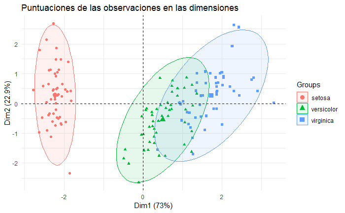

```r
acp_g= fviz_pca_ind(acp, geom = "point",
                  habillage=iris$Species, addEllipses=TRUE,
                  ellipse.level= 0.95)+
                  labs(title = "Puntuaciones de las observaciones en las dimensiones")+
                  theme_minimal()
print(acp_g)
```

Por último, realizamos un gráfico conjunto de observaciones y variables, etiquetando sólo estas:

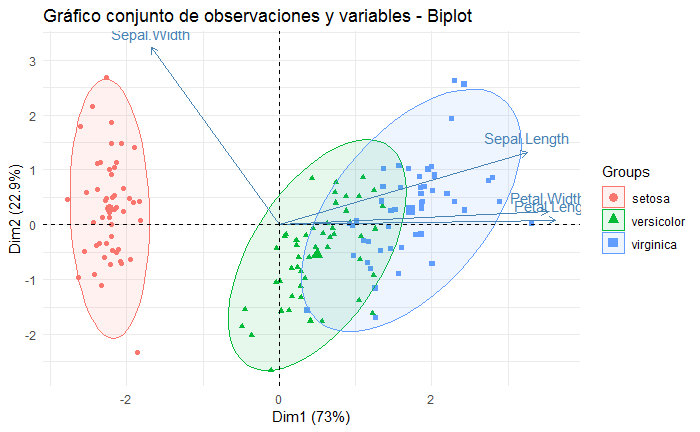

```r
fviz_pca_biplot(acp,  label="var", habillage=iris$Species,
                addEllipses=TRUE, ellipse.level=0.95) +
        labs(title = "Gráfico conjunto de observaciones y variables - Biplot")+
        theme_minimal()
```